# LCM-BIC immunophenotyping clustering in COVID-19 patients Interactive Results and Databases.

Fernando Marín-Benesiu, Lucia Chica-Redecillas, Sergio Cuenca-López, Carmen Entrala-Bernal, Sara Martín-Esteban, Maria Jesús Alvarez-Cubero, Luis Javier Martínez-González.

**Group Search for molecular biomarkers associated with genetically based diseases. Universidad de Granada, España.**

Additional resources for our study in the Computational and Structural Biotechnology Journal: Integration of T cell repertoire, CyTOF, genotyping and symptomatology data reveals subphenotypic variability in patients with SARS-CoV-2 infection.

## Table of Contents

- 1.OUR STUDY
  - 1.1 Abstract
  - 1.2 Main objective
  - 1.3 Specific objectives
  - 1.4 Data avaliability
  - 1.5 References and contact
- 2. MAIN RESULTS
  - 2.1 Exploratory Analysis and Latent Class Model (LCM) Clustering
  - 2.2 Variable Distribution Across Clusters
  - 2.3 CDR3b Sequence Signatures Across Clusters
  - 2.4 SARS-CoV-2-Reactive CDR3b Sequences
- 3. INTERACTIVE DATABASE
  - 3.1 Standarized LCM-BIC variables
  - 3.2 Antigen affinities of Deep-learning predicted sequences

# OUR STUDY

Additional interactive resources from the study results are available on this website: Integration of T Cell Repertoire, CyTOF, genotyping and symptomatology data reveals subphenotypic variability in COVID-19 Patients. The website is divided into a first section describing the results with graphs and interactive tables, followed by a second section consisting of the creation of a searchable database.

The **new database** stores the TCRs with the highest predictive capacity in the comparisons obtained in our study, together with information of interest such as the V and J allele encoded as well as the epitope, antigen and corresponding pathogen to which they are related.

## Abstract

COVID-19 manifests a broad spectrum of clinical outcomes , from asymptomatic cases to severe disease. While several biomarkers have been proposed, comprehensive immunological analyses integrating mass cytometry (CyTOF) and T-cell receptor sequencing (TCRseq) data remain limited. In this study, we applied the Latent Class Model based on the Bayesian Information Criterion (LCM-BIC) algorithm to integrate immunophenotyping, including monocyte-macrophage counts from CyTOF, T-cell receptor repertorie data via TCRseq, SNPs data from *ACE2* (rs2285666), *MX1* (rs469390), and *TMPRSS2* (rs2070788), and symptomatology data from 61 Spanish COVID-19 patients (33 mild, 28 severe). We identified three novel and distinct patient clusters with significant differences in TCR diversity, monocyte subpopulations, and V allele usage and disease outcome. Cluster 1 was predominantly enriched in severe cases, characterized by unique immunological features. Deep learning analysis of TCR amino acid sequences further distinguished Cluster 1 from the others, identifying SARS-CoV-2-specific TCR sequences associated with disease severity. In addition, analysis of residue sensitivity of cluster 1 SARS-CoV-2-specific TCR sequences further identified conserved aminoacids located in key central positions of the complementarity-determining region 3. This study highlights the value of integrating immunophenotyping and genetic profiling to identify novel immunological markers and patterns, aiding in the stratification and management of COVID-19 patients based on their immune profiles and genetic background.

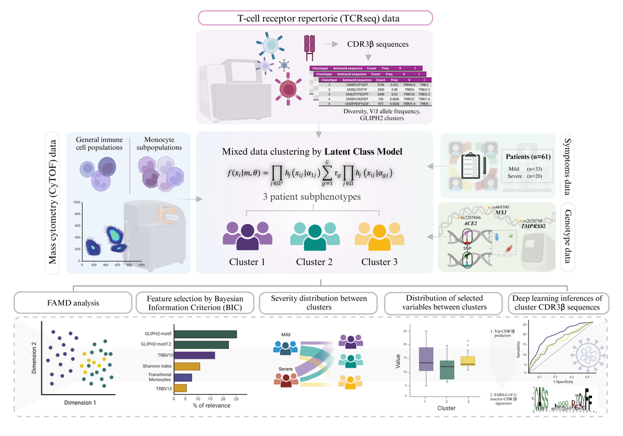

## Main objective

The main objective of this study was to apply the integration of immunophenotyping data for the identification of subphenotypes in COVID-19 patients to achieve a more accurate stratification.

## Specific objectives

- Integrate bulk-TCRβ seq, CyTOF, genotyping and symptomatology data into the latent class model (LCM) as an unsupervised machine learning technique to detect patient subgroups.
- Study the distribution of observations and groups created by LCM using univariate and multivariate analysis.
- Detect clonotypes and critical residues in the CDR3b sequence among the groups created by LCM, based on deep learning inference.
- Filter and study critical residues, affinity for antigens and detection of structural motifs of the most predictive clonotypes, using tools based on sequence alignment.

## Data avaliability

Source code of the R and Python Jupyter scrips can be found in https://github.com/fmarinb/COVID19_LCM_integration and in Figshare with doi: 10.6084/m9.figshare.26994868.

Datasets can be found at the European Genome Phenome Archive (EGA) with datasets IDs EGAD50000000840 (https://ega443 archive.org/datasets/EGAD50000000840) and EGAD50000000477 (https://ega444 archive.org/datasets/EGAD50000000477)

## References and contact:

Marín-Benesiu, F., Chica-Redecillas, L., Arenas-Rodríguez, V. *et al.* The T-cell repertoire of Spanish patients with COVID-19 as a strategy to link T-cell characteristics to the severity of the disease. *Hum Genomics* **18**, 94 (2024). https://doi.org/10.1186/s40246-024-00654-0

fernando.marin@genyo.es

# MAIN RESULTS

## Exploratory Analysis and Latent Class Model (LCM) Clustering

A Factor Analysis of Mixed Data (FAMD) was conducted before and after clustering with a Latent Class Model (LCM). Before clustering, TCR diversity, clonality, and monocyte markers showed moderate influence, but no significant separation was found between mild and severe cases. After LCM clustering, patients were grouped into **three distinct clusters**, with stronger contributions from V alleles and monocyte profiles. While severity alone was not statistically significant, **clear differences emerged between clusters** (p = 0.001).

[interactive chart not shown]

**Figure 1.** Post-LCM dataset dimensionality is reduced using a FAMD plot and labelled according to the cluster generated by the LCM-BIC model. Groups represent patient clusters obtained by LCM-BIC.

## Variable Distribution Across Clusters

[interactive chart not shown]

## CDR3b Sequence Signatures Across Clusters

Further analysis identified **amino acid patterns** in Cluster 1, with central positions 5–7 enriched in glutamic acid (E), aspartic acid (D), and proline (P), supporting the presence of **distinct CDR3b signatures** with potential relevance in disease progression.

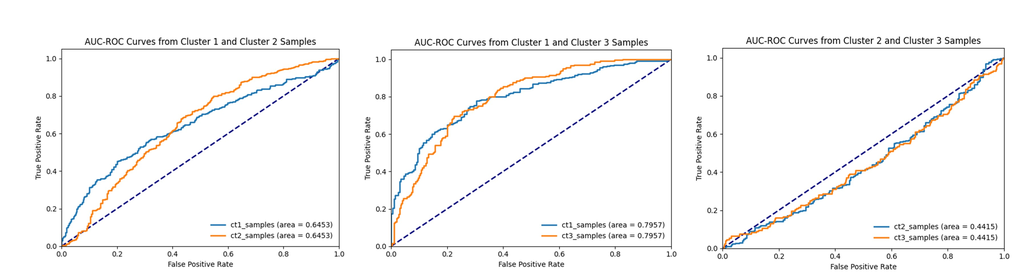

**Figure 3**. AUC-ROC curves of the cluster 1 vs cluster 2 (left), cluster 1 vs cluster 3 (center), and cluster 2 vs cluster 3 (right) are presented. The analyses were validated using 100 Monte Carlo simulations and a 75% training and 25% test split using DeepTCR’ s supervised analysis utilities.

## SARS-CoV-2-Reactive CDR3b Sequences

Among the most predictive CDR3b sequences identified between clusters, **up to ~29% showed reactivity to SARS-CoV-2**, with little or no overlap between Cluster 1 and the others. A group of **59 reactive sequences** specific to Cluster 1 exhibited conserved central-distal residues, particularly at **position 6**, and were divided into two subgroups based on sequence similarity. These findings suggest that **Cluster 1 harbors unique SARS-CoV-2-specific TCR signatures**, reinforcing its immunological distinctiveness.

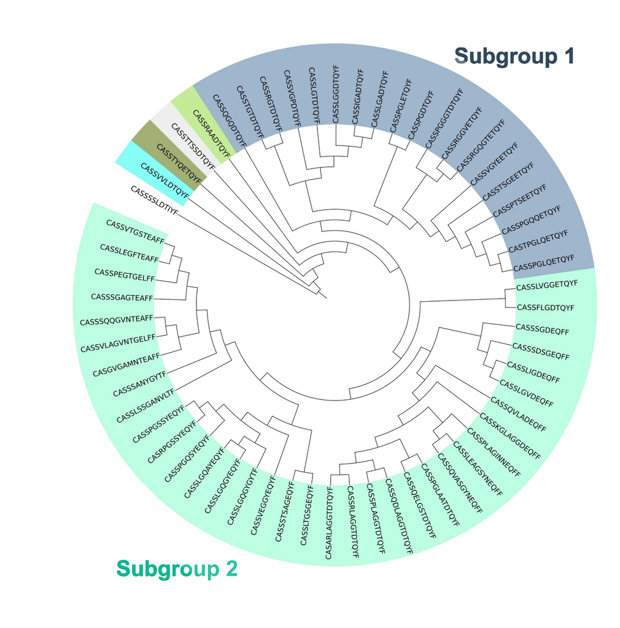

**Figure 4.** A multiple sequence aligment-generated dendrogram of the 59 common SARS-CoV-2-reactive CDR3b sequences in cluster 1 in both comparisons. Jalview2.11.3.2 software with the BLOSUM62 substitution matrix was used for the tree diagram. The two major subgroups identified in the tree are shown in color along with the CDR3b sequences that fall outside them.

# INTERACTIVE DATABASE

In order to offer an ordered and detailed information of the main results of our study for public use, we have generated a database consisting of a set of interactive tables in which researchers can filter and sort their content. In this section, authors could obtain relevant information for their studies from the quick and easy contrast with our results.

**An example case** would be the query of COVID-19 reactive CDR3 sequences with high predictive capacity in our cohort.

## Standarized LCM-BIC variables

For information regarding how the data was obtained, how the study variables were calculated, and additional information on the metrics performed, please refer to our **PDF Supplementary Material**.

| Sample | Cluster | Severity | Age group | Combined Severity and Age group | Shannon Wiener Index | Gini Simpson Index | D50 | Gini s coefficient | Rare | Small | Large | Hyperexpanded | TRBV10 | TRBV11 1 | TRBV11 2 | TRBV11 3 | TRBV12 3 | TRBV12 5 | TRBV14 | TRBV15 | TRBV16 | TRBV18 | TRBV19 | TRBV27 | TRBV3 1 | TRBV4 3 | TRBV5 1 | TRBV5 5 | TRBV6 1 | … |
| --- | --- | --- | --- | --- | --- | --- | --- | --- | --- | --- | --- | --- | --- | --- | --- | --- | --- | --- | --- | --- | --- | --- | --- | --- | --- | --- | --- | --- | --- | --- |
| Sample 1 | 1 | Mild | &gt;55 | Mild-&gt;55 | 0.75 | 0.98833 | 1296 | 0.64146 | 0.405 | 0.14781 | 0.13778 | 0.23576 | 0.00442 | 0.00136 | 0.01417 | 0.0012 | 0.01269 | 0.00109 | 0.00603 | 0.01098 | 0.00036 | 0.01715 | 0.03785 | 0.0567 | 0.01133 | 0.06559 | 0.0386 | 0.00736 | 0.01149 | … |
| Sample 2 | 2 | Mild | &lt;55 | Mild-&lt;55 | 0.90742 | 0.9996 | 13762 | 0.5148 | 0.53682 | 0.2583 | 0.06317 | 0.01108 | 0.00177 | 0.00245 | 0.02121 | 0.00484 | 0.02291 | 0.00182 | 0.00965 | 0.01538 | 0.00052 | 0.0165 | 0.04682 | 0.0463 | 0.01898 | 0.02243 | 0.05404 | 0.01377 | 0.01872 | … |
| Sample 3 | 3 | Mild | &lt;55 | Mild-&lt;55 | 0.93963 | 0.99978 | 25666 | 0.44257 | 0.62408 | 0.25501 | 0.04394 | 0 | 0.00428 | 0.00306 | 0.02587 | 0.00183 | 0.02445 | 0.00285 | 0.01145 | 0.01241 | 0.00053 | 0.0199 | 0.06839 | 0.05778 | 0.02851 | 0 | 0.07489 | 0.00867 | 0.02928 | … |
| Sample 4 | 3 | Mild | &lt;55 | Mild-&lt;55 | 0.95003 | 0.99981 | 40174 | 0.36795 | 0.74639 | 0.16392 | 0.03254 | 0 | 5e-05 | 0.00462 | 0.02003 | 0.00217 | 0.02728 | 0.00377 | 0.01403 | 0.02153 | 0.00073 | 0.01961 | 0.0796 | 0.03752 | 0.02355 | 0.00888 | 0.06308 | 0.01317 | 0.02354 | … |
| Sample 5 | 1 | Mild | &lt;55 | Mild-&lt;55 | 0.7435 | 0.98904 | 529 | 0.70643 | 0.30665 | 0.1939 | 0.1973 | 0.19216 | 0.00135 | 0.01653 | 0.01459 | 0.00493 | 0.02232 | 0.00153 | 0.01597 | 0.00927 | 0.00026 | 0.01572 | 0.03179 | 0.0811 | 0.01788 | 0.00802 | 0.03298 | 0.00776 | 0.01788 | … |
| Sample 6 | 1 | Mild | &gt;55 | Mild-&gt;55 | 0.82047 | 0.99052 | 4707 | 0.61639 | 0.33807 | 0.31501 | 0.08809 | 0.15632 | 7e-05 | 0.00261 | 0.01432 | 0.00146 | 0.01658 | 0.00408 | 0.03188 | 0.02065 | 0.00125 | 0.01301 | 0.0365 | 0.04752 | 0.01696 | 0.03382 | 0.04061 | 0.01018 | 0.01465 | … |
| Sample 7 | 2 | Mild | &lt;55 | Mild-&lt;55 | 0.89719 | 0.99911 | 15347 | 0.51067 | 0.54656 | 0.24877 | 0.10677 | 0.01556 | 0.00234 | 0.00245 | 0.02352 | 0.00308 | 0.02506 | 0.00863 | 0.00961 | 0.01712 | 0.00053 | 0.01669 | 0.05904 | 0.04397 | 0.0255 | 0.01798 | 0.04773 | 0.00945 | 0.0206 | … |
| Sample 8 | 1 | Mild | &gt;55 | Mild-&gt;55 | 0.73686 | 0.96884 | 1484 | 0.67493 | 0.30888 | 0.25713 | 0.05608 | 0.28461 | 2e-05 | 0.00358 | 0.0128 | 0.19632 | 0.01963 | 0.00026 | 0.00285 | 0.00542 | 0.00027 | 0.00733 | 0.03138 | 0.06234 | 0.00914 | 0.01022 | 0.04528 | 0.00842 | 0.0141 | … |
| Sample 9 | 2 | Mild | &lt;55 | Mild-&lt;55 | 0.88298 | 0.99701 | 6229 | 0.52025 | 0.08475 | 0.64117 | 0.08206 | 0.09771 | 2e-05 | 0.00453 | 0.01584 | 0.00153 | 0.02535 | 0.00318 | 0.01576 | 0.01577 | 0.00093 | 0.0537 | 0.05393 | 0.06078 | 0.01853 | 0.01351 | 0.02482 | 0.00802 | 0.01461 | … |
| Sample 10 | 2 | Mild | &lt;55 | Mild-&lt;55 | 0.94708 | 0.99992 | 31390 | 0.41164 | 0.68001 | 0.21786 | 0.01763 | 0 | 0.00442 | 0.00341 | 0.03206 | 0.0019 | 0.0276 | 0.00283 | 0.011 | 0.02139 | 0.00057 | 0.02058 | 0.07459 | 0.05365 | 0.02703 | 0 | 0.073 | 0.01678 | 0.03443 | … |

[output cut: 51 more lines]

## Antigen affinities of Deep-learning predicted sequences

This analysis focuses on the top CDR3 sequences identified as highly predictive (AUC ≥ 0.99) in the supervised DeepTCR models comparing Cluster 1 vs Cluster 2 and Cluster 1 vs Cluster 3. To investigate their potential antigen specificity, these sequences were further analyzed using TCRmatch, a tool from the Immune Epitope Database (IEDB) that predicts TCR specificity based on sequence similarity.

TCRmatch computes a similarity score ranging from 0 (no similarity) to 1 (perfect match) using a k-mer-based algorithm that captures both exact amino acid matches and biochemical motif similarities. This scoring system allows assessment of functional convergence between query CDR3 sequences and known antigen-specific TCRs.

The following table summarizes the key information for each analyzed sequence, including:

1. **CDR3 amino acid sequence** from our dataset with a validated match in the IEDB.
2. **Trimmed CDR3β sequence** (removal of first and last residues) used for compatibility with TCRmatch.
3. **TCRmatch similarity score** indicating the degree of similarity between the query CDR3 and known IEDB CDR3 sequences.
4. **Amino acid sequence of the matched epitope**, indicating potential antigenic specificity.
5. **Full and abbreviated names of the source protein** from which the antigen is derived.
6. **Organism of origin** for the identified antigen.
7. **Patient cluster** to which the query CDR3 sequence belongs.
8. **Supervised DeepTCR model** (Cluster 1 vs 2 or Cluster 1 vs 3) where the sequence was originally identified.

This combined approach enables the exploration of possible functional relevance and antigenic targets of key CDR3 sequences identified through machine learning, providing biological context to the computational predictions.

For information regarding the DeepTCR supervised models protocol and the TCRmatch approach, please refer to our **PDF Supplementary Material**.

| Trimmed TCRmatch imput | Complete CDR3 beta sequence | Match sequence | score | Receptor Group | Epitope | Antigen | Organism | Cluster | Comparison |
| --- | --- | --- | --- | --- | --- | --- | --- | --- | --- |
| ASSLEAGSYNEQF | CASSLEAGSYNEQFF | ASSLEAGSYNEQF | 1 | 95511 | MIELSLIDFYLCFLAFLLFLVLIML | ORF7b [Severe acute respiratory syndrome coronavirus 2] | SARS-CoV2 | 1 | 1 v 2 |
| ASSLEAGSYNEQF | CASSLEAGSYNEQFF | ASSLEAGAYNEQF | 0.97684 | 95399 | KLSYGIATV |  |  | 1 | 1 v 2 |
| ASSSGKETQY | CASSSGKETQYF | ASSSGEETQY | 0.97228 | 55629 | KLGGALQAK | 55 kDa immediate-early protein 1 | Human herpesvirus 5 strain AD169 (Human cytomegalovirus (strain AD169)) | 1 | 1 v 2 |
| ASSRGQGTETQY | CASSRGQGTETQYF | ASSRGQGTDTQY | 0.9726 | 119934 | LITGRLQSLQTYV | surface glycoprotein [Severe acute respiratory syndrome coronavirus 2] | SARS-CoV2 | 1 | 1 v 2 |
| ASSSGQGLNTEAF | CASSSGQGLNTEAFF | ASSSGQGMNTEAF | 0.97847 | 21012 | PKYVKQNTLKLAT | Hemagglutinin precursor | Influenza A virus | 1 | 1 v 2 |
| ASSSGQGLNTEAF | CASSSGQGLNTEAFF | ASSSGQGVNTEAF | 0.97609 | 126379 | SEHDYQIGGYTEKW | ORF3a protein [Severe acute respiratory syndrome coronavirus 2] | SARS-CoV2 | 1 | 1 v 2 |
| ASSSGQGLNTEAF | CASSSGQGLNTEAFF | ASSTGQGLNTEAF | 0.98057 | 128713 | SEHDYQIGGYTEKW | ORF3a protein [Severe acute respiratory syndrome coronavirus 2] | SARS-CoV2 | 1 | 1 v 2 |
| ASSPGAANQPQH | CASSPGAANQPQHF | ASSPGASNQPQH | 0.97668 | 107065 | HTTDPSFLGRY | orf1ab polyprotein [Severe acute respiratory syndrome coronavirus 2] | SARS-CoV2 | 1 | 1 v 2 |
| ASSLAGGSTGELF | CASSLAGGSTGELFF | ASSLAGGSTGELF | 1 | 89918 | KLNVGDYFV | orf1ab polyprotein [Severe acute respiratory syndrome coronavirus 2] | SARS-CoV2 | 1 | 1 v 2 |
| ASSLAGGSTGELF | CASSLAGGSTGELFF | ASSLVGGSTGELF | 0.97235 | 102479 | TLIGDCATV | orf1ab polyprotein [Severe acute respiratory syndrome coronavirus 2] | SARS-CoV2 | 1 | 1 v 2 |

[output cut: 7621 more lines]